# A3: Incarceration

### Introduction

Racism in the United States has continued to exist since its creation, surviving far past the end of slavery, segregation, and countless other forms of discrimination, all of which promised to bring an end to the issue. In the modern day, this act of injustice manifests itself quite notably within our prison system, excused as an essential means of upholding a “just” society. In order to more closely examine and analyze this issue, this page intends to use the *Incarceration Trends Dataset* to compare the populations of various races to the incarcerated populations of the same races in order to identify inequality in the proportion of incarcerated individuals between these groups. It will also look at how these variables change over time to identify any historical trends, as well as how they relate to geographical regions to see if location plays any significant role in the discriminatory incarceration within the United States.

### Summary Information

Looking into the most complete recent year in the dataset, 2016, it was found that the total percentage of the study population that was incarcerated was 0.9%, however this wasn’t spread proportionately across the five studied racial groups: Asian American / Pacific Islander, Black, Latinx, Native American, and White. Rather, Asian Americans / Pacific Islanders had the lowest ratio, falling significantly below the expected incarceration rate with only 0.1% of the population being incarcerated, while Black Americans were imprisoned at the highest rate, well above their expected proportion sitting at 2.65%. In other words, Black Americans make up only 12.93% of the total population, yet 38.17% of the incarcerated population. 2016 wasn’t even the peak of their imprisonment though, that being 9 years ago in 2007 where 356320 Black Americans sat jailed or imprisoned while only 293412 White Americans were incarcerated in the same year.

### The Dataset

This dataset was originally collected by the Vera Institute, and then broken into smaller files for ease of use in this assignment by Melanie Walsh of UW’s iSchool. Vera collected this data by using a combination of federal and state department reports to average the daily amount of prisoners, disaggregated by race, across each county for an annual report of jail population. Prison population data was collected from these reports as the number of prisoners at the end of the year. These results were compiled using sources such as the NCRP, DCRP, ASJ, COJ, CAF, UCR, CDC, USDA, and U.S. Census. This data was collected, according to Vera, “to build and create justice systems that ensure fairness, promote safety, and strengthen communities.” The complete dataset provided by Vera contains 153,811 observations and 121 features, while the smaller subsets used in the assignment have 36 and 28 observations for the prison and jail datasets respectively. One of the main ethical questions that must be considered when working with this data is ‘what were the circumstances and reasons behind the incarceration of the individuals within these racial groups,’ as the data only shows the population incarcerated as a number, not any of the events, policies, or context behind each person’s incarceration. This doubles as one of the dataset’s main limitations: it lacks context surrounding the reason of incarceration. Without this vital information, it is easy to jump to conclusions about trends in the data, but lacking knowledge of the full circumstances behind the data, it is impossible to know the full story from this dataset alone. Another major limitation of the data is the large amount of unknown values, especially in earlier years, making it difficult to derive any meaningful observations about the missing populations during those times.

### Trends Over Time Chart

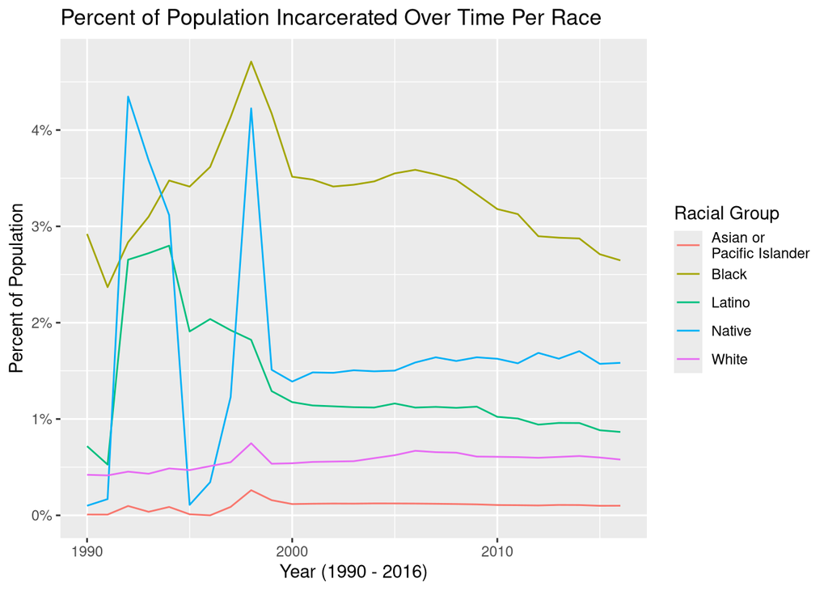

This chart displays the percentage of each racial group studied that was incarcerated between the years 1990 and 2016. Its purpose is to showcase the discrepancy between the groups, as well as trends within each group as time passes. For example, Black Americans have a significantly higher percentage of their population incarcerated across nearly all of the years studied compared to other groups, while Asian Americans, Pacific Islanders, and White Americans consistently have a much lower percentage. The chart also effectively displays major changes in percentage of the populations incarcerated, such as the jumps in 1992 and falls in 1995 in for Native and Latino populations, or the spike in 1998 for all populations except Latinos. Observing these trends could help link historical policies or events to their effects on specific racial groups, and uncover potentially discriminatory and unjust effects not initially apparent. Overall, the chart shows a general increase in incarcerated populations around 1992, and a decrease beginning after 1998, with much variability in the years between for most racial groups.

### Variable Comparison Chart

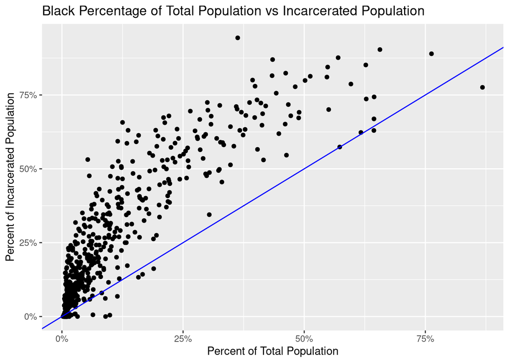

This chart shows how the percentage of Black Americans in the total population relates to the percentage they make up in the incarcerated population of the same location. Its purpose is to check if Black Americans are being incarcerated at a level proportional to their share of the population. If this were the case, the expected visual would have the dots fall on or around a diagonal line where the percent of the total population is about the same as the percent of the incarcerated population, displayed above for reference. From the graph, however, this is clearly not the case, as the vast majority of the dots fall above the line indicating that they are being incarcerated at a rate disproportional to the percentage of the total population that they make up. This further supports the previous results indicating that the United States prison systems could be discriminating Black Americans, as they are consistently over represented within the incarcerated populations.

### Map

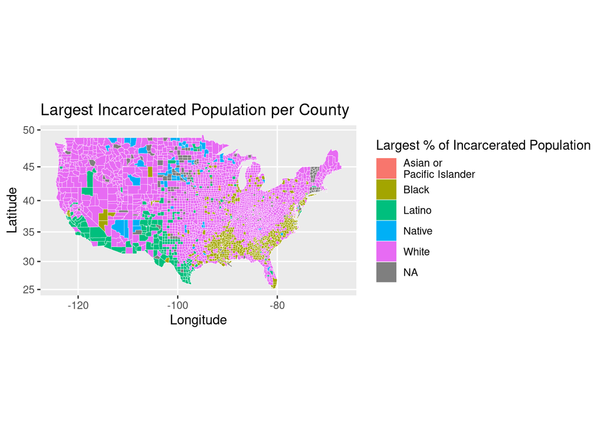

This map shows which racial group makes up the largest percentage of the incarcerated population in each county. The purpose of it is to examine if there are any geographical trends that might suggest discrimination in certain areas. The results shown indicate that the majority of the United States counties have White Americans making up most of their incarcerated populations, however there are some interesting exceptions towards the bottom of the map. Here we can see that in the southeast section of America, there is a large amount of counties with Black Americans making up the majority of their incarcerated population, and in the southwest there is a large percentage made up by Latinos. While this could just have to do with populations of those groups in those areas, it could also be a reminder of the conflict and discrimination against those groups in the United State’s history.